# IODS course project

Fitting the Linear Discriminant Analysis to this dataset, taking crime rate as a target, and all other variables as predictor variables, we can model the difference between different classes of data (low,med-low,med-high, high) having crime as a target variable. With the bidimensional plot below, we can understand and see the relationship between variables and crime occurences.

```
## Call:
## lda(crime ~ ., data = train)
##
## Prior probabilities of groups:
##       low   med_low  med_high      high
## 0.2450495 0.2400990 0.2574257 0.2574257
##
## Group means:
##                   zn      indus        chas        nox          rm
## low       1.01410924 -0.9056887 -0.15302300 -0.8890524  0.44504884
## med_low  -0.05360647 -0.3242109 -0.06938576 -0.5761960 -0.07610039
## med_high -0.40395960  0.1868527  0.21980846  0.3326381  0.04837715
## high     -0.48724019  1.0170690 -0.04518867  1.0114872 -0.46878271
##                 age        dis        rad        tax     ptratio
## low      -0.9226974  0.8963083 -0.6883741 -0.7353521 -0.47822523
## med_low  -0.3429724  0.3919125 -0.5390602 -0.4782209 -0.09422279
## med_high  0.4490584 -0.3649899 -0.4385580 -0.3311108 -0.21218998
## high      0.7905806 -0.8473075  1.6386213  1.5144083  0.78135074
##               black       lstat       medv
## low       0.3788845 -0.79277360  0.5450246
## med_low   0.3472818 -0.16017015  0.0188515
## med_high  0.1046399  0.03375848  0.1192768
## high     -0.7945450  0.85316639 -0.6308548
##
## Coefficients of linear discriminants:
##                 LD1         LD2         LD3
## zn       0.11253404  0.73457501 -1.05026417
## indus    0.03602580 -0.18337705  0.22233988
## chas    -0.10767187 -0.09357509  0.02016677
## nox      0.37965845 -0.59880041 -1.32249852
## rm      -0.17227477 -0.09608891 -0.08225217
## age      0.19786415 -0.42854170 -0.15732582
## dis     -0.08213196 -0.23779574  0.35925904
## rad      3.37839005  1.01472996 -0.13645217
## tax      0.05756732 -0.13759986  0.78846951
## ptratio  0.13596203  0.01212104 -0.35705913
## black   -0.12452057  0.02583445  0.19087224
## lstat    0.19873040 -0.18022480  0.39423948
## medv     0.21588073 -0.26865979 -0.19829032
##
## Proportion of trace:
##    LD1    LD2    LD3
## 0.9539 0.0361 0.0100
```

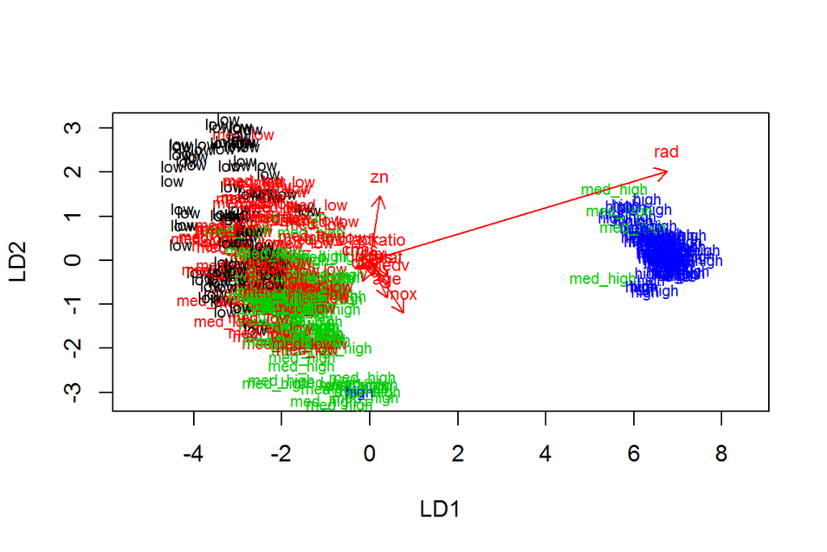

**5) LDA Prediction**

```
##           predicted
## correct    low med_low med_high high
##   low       13      12        3    0
##   med_low    3      17        9    0
##   med_high   0       4       16    2
##   high       0       0        0   23
```

**6) Distance between Observations**

```
##    Min. 1st Qu.  Median    Mean 3rd Qu.    Max.
##   1.119  85.620 170.500 226.300 371.900 626.000
```

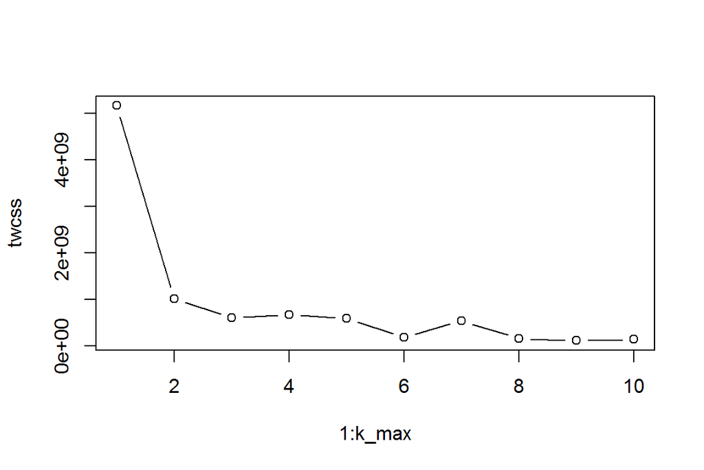

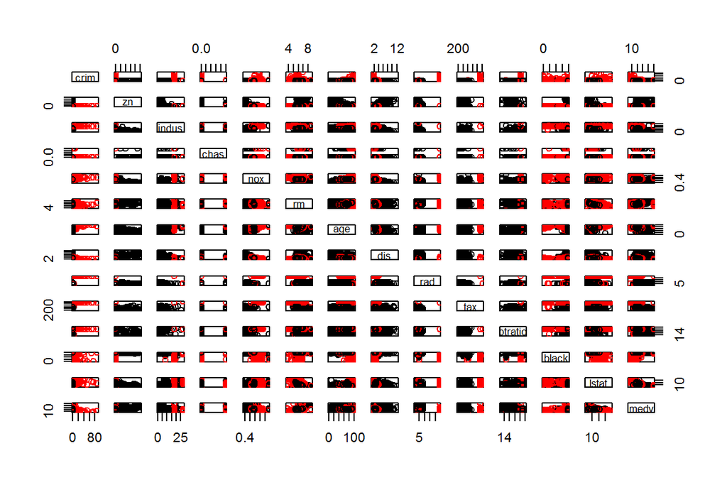

# Dimensionality Reduction Techniques

**The following dataset is being used for the purpose of this statistical analysis: *Human*, gathered and processed by the UNDP (United Nations Development Program)** **It is the objective of this report to analyse the data through R, with a concise explanation of each step and codes used.**

**1) Structure of the Data**

The *Human* data consists of 155 observations within 8 variables. Due analysis purposes, only the following variables were taken into consideration in this report: Female & Male education ratio (FMedu_ratio); Female & Male labor ratio (FMlab_ratio); Life Expectancy (Life); Expected Years of Education (Exp); Gross National Income (GNI); Maternal Mortality Ratio (Mater); Adolescent Birth Rate (Adol); Percent Represented in Parliament (Parl). The 155 observations account for all countries analysed during the data gathering process.

```
## [1] 155   8
```

```
## 'data.frame':    155 obs. of  8 variables:
##  $ FMedu_ratio: num  1.007 0.997 0.983 0.989 0.969 ...
##  $ FMlab_ratio: num  0.891 0.819 0.825 0.884 0.829 ...
##  $ Life       : num  81.6 82.4 83 80.2 81.6 80.9 80.9 79.1 82 81.8 ...
##  $ Exp        : num  17.5 20.2 15.8 18.7 17.9 16.5 18.6 16.5 15.9 19.2 ...
##  $ GNI        : int  64992 42261 56431 44025 45435 43919 39568 52947 42155 32689 ...
##  $ Mater      : int  4 6 6 5 6 7 9 28 11 8 ...
##  $ Adol       : num  7.8 12.1 1.9 5.1 6.2 3.8 8.2 31 14.5 25.3 ...
##  $ Parl       : num  39.6 30.5 28.5 38 36.9 36.9 19.9 19.4 28.2 31.4 ...
```

```
##   FMedu_ratio      FMlab_ratio          Life            Exp
##  Min.   :0.1717   Min.   :0.1857   Min.   :49.00   Min.   : 5.40
##  1st Qu.:0.7264   1st Qu.:0.5984   1st Qu.:66.30   1st Qu.:11.25
##  Median :0.9375   Median :0.7535   Median :74.20   Median :13.50
##  Mean   :0.8529   Mean   :0.7074   Mean   :71.65   Mean   :13.18
##  3rd Qu.:0.9968   3rd Qu.:0.8535   3rd Qu.:77.25   3rd Qu.:15.20
##  Max.   :1.4967   Max.   :1.0380   Max.   :83.50   Max.   :20.20
##       GNI             Mater             Adol             Parl
##  Min.   :   581   Min.   :   1.0   Min.   :  0.60   Min.   : 0.00
##  1st Qu.:  4198   1st Qu.:  11.5   1st Qu.: 12.65   1st Qu.:12.40
##  Median : 12040   Median :  49.0   Median : 33.60   Median :19.30
##  Mean   : 17628   Mean   : 149.1   Mean   : 47.16   Mean   :20.91
##  3rd Qu.: 24512   3rd Qu.: 190.0   3rd Qu.: 71.95   3rd Qu.:27.95
##  Max.   :123124   Max.   :1100.0   Max.   :204.80   Max.   :57.50
```

**2)Graphical overview of the data and summary**

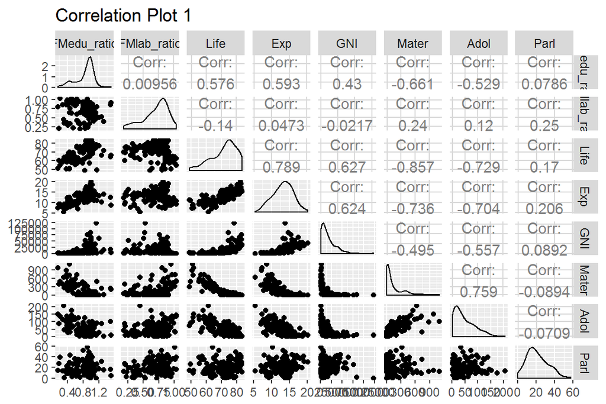

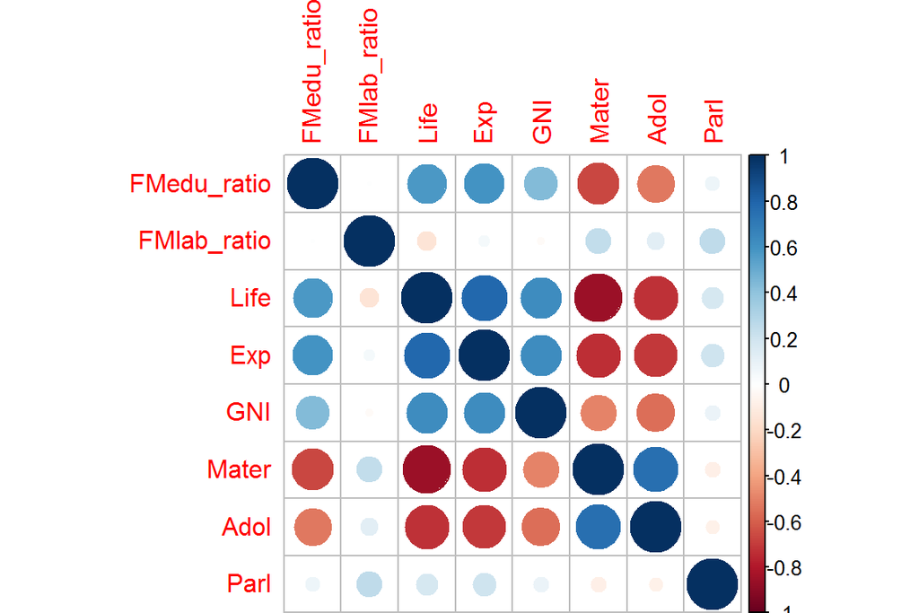

**3)PCA**

The principal component analysis, also known as PCA, is a dimensionality reduction technique that reduces any number of measured and correlated variables into a few uncorrelated components. With the reduced dimensionality, it is easier to analyse and draw graphs that otherwise would present too many dimensions. Let’s take the “human” data, for example. An initial PCA shows a rather confusing and concentrated plot. PCA usually requires standardizing the data before seeing clearly results, as the variables can be too different.

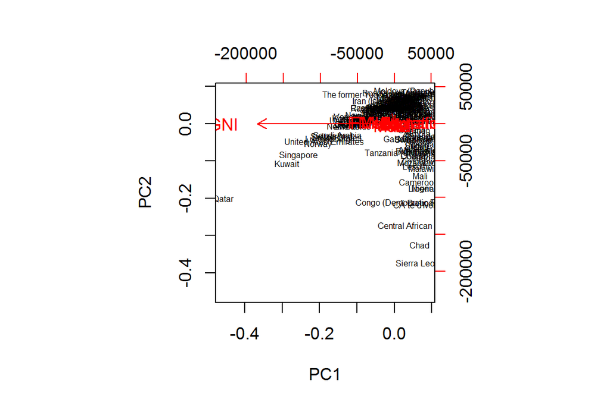

*Standardizing PCA*

After standardizing the data, PCA can be easier analysed. The differences between the variables can be reduced through standardization, which now in turn can offer us an easier way to compare the correlation between variables.The arrows on the following graph, for example, can represent this correlation. Variables *Parl* and *FMlab_ratio*, for example, seem to be correlated and influencing to one of the biplot components, named PC2 in this case. Variables *Mater* and *Adol* , on the other hand, also have a really close correlation, but instead influence to the biplot component PC1, pushing it to the right.Other variables are also correlated and push the data to the left of the graph.

```
##   FMedu_ratio       FMlab_ratio           Life              Exp
##  Min.   :-2.8189   Min.   :-2.6247   Min.   :-2.7188   Min.   :-2.7378
##  1st Qu.:-0.5233   1st Qu.:-0.5484   1st Qu.:-0.6425   1st Qu.:-0.6782
##  Median : 0.3503   Median : 0.2316   Median : 0.3056   Median : 0.1140
##  Mean   : 0.0000   Mean   : 0.0000   Mean   : 0.0000   Mean   : 0.0000
##  3rd Qu.: 0.5958   3rd Qu.: 0.7350   3rd Qu.: 0.6717   3rd Qu.: 0.7126
##  Max.   : 2.6646   Max.   : 1.6632   Max.   : 1.4218   Max.   : 2.4730
##       GNI              Mater              Adol              Parl
##  Min.   :-0.9193   Min.   :-0.6992   Min.   :-1.1325   Min.   :-1.8203
##  1st Qu.:-0.7243   1st Qu.:-0.6496   1st Qu.:-0.8394   1st Qu.:-0.7409
##  Median :-0.3013   Median :-0.4726   Median :-0.3298   Median :-0.1403
##  Mean   : 0.0000   Mean   : 0.0000   Mean   : 0.0000   Mean   : 0.0000
##  3rd Qu.: 0.3712   3rd Qu.: 0.1932   3rd Qu.: 0.6030   3rd Qu.: 0.6127
##  Max.   : 5.6890   Max.   : 4.4899   Max.   : 3.8344   Max.   : 3.1850
```

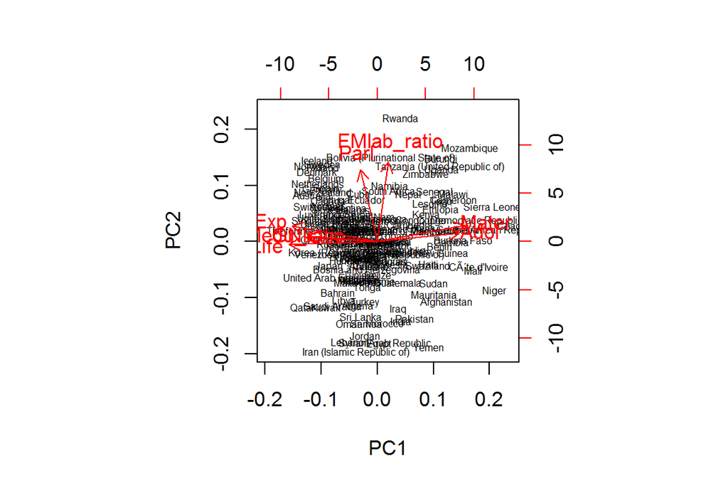

**4)The Tea Dataset**

In order to explain and work with Multiple Correspondence Analysis (MCA), the Tea dataset, from FactoMineR, will be analysed. The data has 300 observations under 36 variables, but for analysis purposes, we will only analyse 6 variables. MCA is a technique that takes multiple categorical variables and seeks to identify associations between levels of those variables. Just like PCA, it is a dimensionality reduction method, representing the totality of the data in 2-3 dimensional spaces.